# CUNY DATA 621 - Business Analytics and Data Mining

Blog 4 - Using LIME in Regression

Walt Wells, 2018

# The Lime Package

The [LIME package](https://github.com/thomasp85/lime) or `Local Interpretable Model-agnostic Explanation` is a port of a python package developed to help illuminate the decision making behind black box models.

It can be used with by incorporating a model and a new observation, create an ‘explainer object’, and then detail why the model made a given prediction. This can be useful for diagnostics and business purposes alike.

```r
if (!require('caret')) install.packages('caret')
if (!require('lime')) install.packages('lime')
```

## Demo

To demonstrate the package, we’ll use the crime data from HW 3 and a sample model. Some simple transformations are done to the data to prepare for the modeling step.

```r
set.seed(121)
train <- read.csv('https://raw.githubusercontent.com/wwells/CUNY_DATA_621/master/HW/HW3/Data/crime-training-data_modified.csv')
test <- read.csv('https://raw.githubusercontent.com/wwells/CUNY_DATA_621/master/HW/HW3/Data/crime-evaluation-data_modified.csv')

trainchas <- as.factor(train$chas)
train$chas <- NULL
traintarget <- as.factor(train$target)
train$target <- traintarget
testchas <- as.factor(test$chas)
test$chas <- NULL
train$rad[train$rad == 24] <- 9

mod4 <- train(target ~ age + dis + tax + medv,
            data = train,
            method = "glm", family = "binomial",
            trControl = trainControl(
                  method = "cv", number = 10,
                  savePredictions = TRUE),
            tuneLength = 5,
            preProcess = c("center", "scale"))
```

Now that we have our model, let’s make and explain some predictions using LIME.

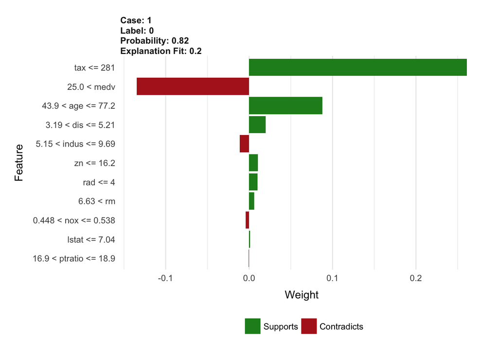

```r
set.seed(121)
explainer <- lime(train, mod4)

obsv1 <- test[c(1),]
explanation <- explain(obsv1, explainer, n_labels = 1, n_features=11)
plot_features(explanation, ncol=1)
```

Here we can see that our model predicts label 0, with a probability of 0.82. The observations in green are supported by model parameters and increase the probability of being predicted as a given label. The values in red detract and lower our probability.

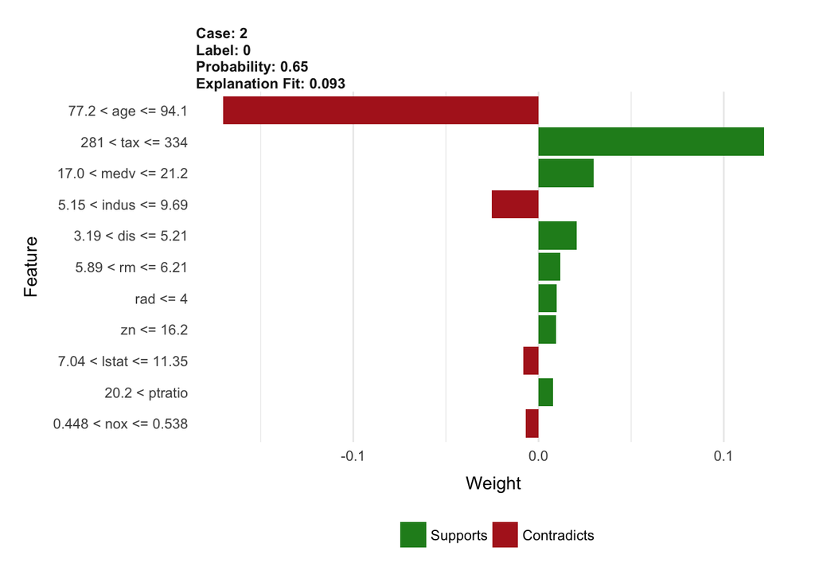

```r
set.seed(121)
obsv2 <- test[c(2),]
explanation <- explain(obsv2, explainer, n_labels = 1, n_features=11)
plot_features(explanation, ncol=1)
```

Like the first prediction, this case is also expected to be a label of 0, however, it has a much lower probability. We can see that while the other features push the prediction towards 0, the age variable contradicts the expectations of the model.

## Conclusion

The LIME package is extremely useful for understanding how a model behaves and what features are driving any given prediction. For more information, or to understand the underlying methodology, visit: https://github.com/marcotcr/lime